# Bayesian Statistics

Omid Shams Solari

Spring 2019, STAT200B

One distinguishing characteristic of high-throughput data is that although we want to report on specific features, we observe many related outcomes. For example, we measure the expression of thousands of genes, or the height of thousands of peaks representing protein binding, or the methylation levels across several CpGs. However, most of the statistical inference approaches we have shown here treat each feature independently and pretty much ignores data from other features. We will learn how using statistical models provides power by modeling features jointly. The most successful of these approaches are what we refer to as hierarchical models, which we explain below in the context of Bayesian statistics.

## Bayes theorem

We start by reviewing Bayes theorem. We do this using a hypothetical cystic fibrosis test as an example. Suppose a test for cystic fibrosis has an accuracy of 99%. We will use the following notation:

$$Prob(+| D = 1) = Prob(-|D = 0 ) = 0.99$$

with $+$ meaning a positive test and $D$ representing if you actually have the disease (1) or not (0).

$$Pr(A|B)=\frac{Pr(B|A)Pr(A)}{Pr(B)}$$
This equation applied to our problem becomes:

$$\begin{aligned}
Prob(D = 1 | +) &= \frac{P(+| D = 1 ).P(D = 1)}{Prob( + )}\\
&=\frac{Prob( + | D = 1).P( D = 1 )}{Prob(+| D = 1 ).P( D = 1 ) + Prob( + | D = 0 ) .Prob( D = 0 )}
\end{aligned}$$

### Simulation

The following simulation is meant to help you visualize Bayes Theorem. We start by randomly selecting 1500 people from a population in which the disease in question has a 5% prevalence.

```r
set.seed(3)
prev <- 1/20
##Later, we are arranging 1000 people in 80 rows and 20 columns
M <- 50 ; N <- 30
##do they have the disease?
d<-rbinom(N*M,1,p=prev)
```

Now each person gets the test which is correct 90% of the time.

```r
accuracy <- 0.9
test <- rep(NA,N*M)
##do controls test positive?
test[d==1]  <- rbinom(sum(d==1), 1, p=accuracy)
##do cases test positive?
test[d==0]  <- rbinom(sum(d==0), 1, p=1-accuracy)
```

How many false positives are there? How many true positives? How do you interpret this result?

Plot heatmaps of the population, positives and negatives and color code population values.

Because there are so many more controls than cases, even with a low false positive rate, we get more controls than cases in the group that tested positive (code not shown):

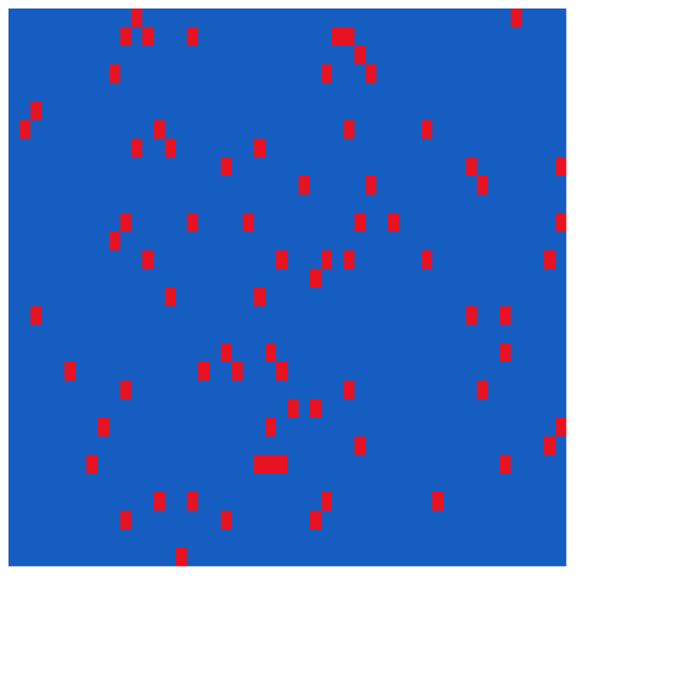

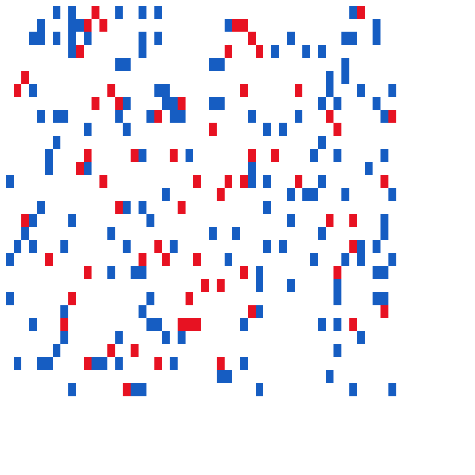

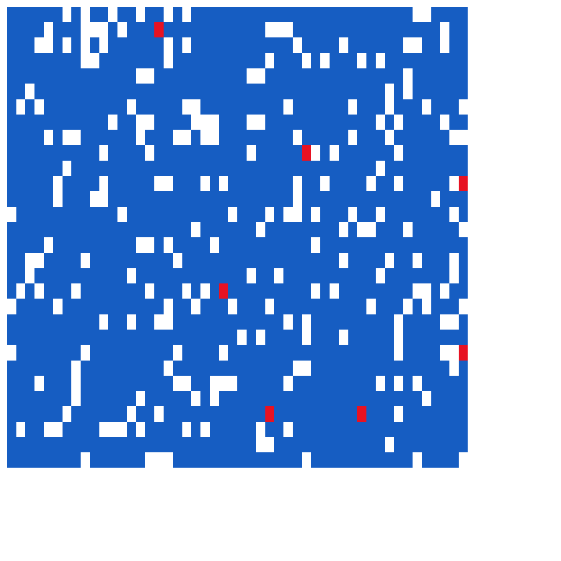

### Bayes in practice

Jose Iglesias is a professional baseball player. In April 2013, when he was starting his career, he was performing rather well:

| Month | At Bats | H | AVG |
| --- | --- | --- | --- |
| April | 20 | 9 | .450 |

The batting average (AVG) statistic is one way of measuring success. Roughly speaking, it tells us the success rate when batting. An AVG of $0.450$ means Jose has been successful $45\%$ of the times he has batted (At Bats) which is rather high as we will see. Note, for example, that no one has finished a season with an AVG of $0.400$ since Ted Williams did it in 1941! To illustrate the way hierarchical models are powerful, we will try to predict Jose’s batting average at the end of the season, after he has gone to bat over 500 times.

With the techniques we have learned up to now, referred to as frequentist techniques, the best we can do is provide a confidence interval. We can think of outcomes from hitting as a binomial with a success rate of p. So if the success rate is indeed $0.450$, the standard error of just 20 at bats is:

$$\sqrt{\frac{0.450 \times (1-0.450)}{20}} = 0.111$$

This means that our confidence interval is $[0.450-0.222,\ 0.450+0.222]$ or $[0.228,\ 0.672]$.

This prediction has two problems. First, it is very large so not very useful. Also, it is centered at .450 which implies that our best guess is that this new player will break Ted William’s record. If you follow baseball, this last statement will seem wrong and this is because you are implicitly using a hierarchical model that factors in information from years of following baseball. Here we show how we can quantify this intuition.

Based on gathered data over the years we note that the average player had an AVG of $0.275$ and the standard deviation of the population of players was $0.027$. So we can see already that $0.450$ would be quite an anomaly since it is over six SDs away from the mean. So is Jose lucky or the best batter seen in the last 50 years? Perhaps it’s a combination of both. But how lucky and how good is he? If we become convinced that he is lucky, we should trade him to a team that trusts the $0.450$ observation and is maybe overestimating his potential.

### The hierarchical model

The hierarchical model provides a mathematical description of how we came to see the observation of $0.450$. First, we pick a player at random with an intrinsic ability summarized by, for example, $\theta$, then we see 20 random outcomes with success probability $\theta$.

$$\begin{aligned}
\theta &\sim \mathcal{N} (\mu, \tau^2) \ describes \ randomness\ in\ picking\ a\ player\\
Y | \theta &\sim \mathcal{N}(\theta, \sigma^2) \ describes\ randomness\ in\ the\ performance\ of\ this\ particular\ player
\end{aligned}$$

Now, let’s use this model for Jose’s data. Suppose we want to predict his innate ability in the form of his true batting average $\theta$. This would be the hierarchical model for our data:

$$\begin{aligned}
\theta &\sim \mathcal{N} (0.275,0.027^2) \\
Y | \theta &\sim \mathcal{N}(\theta, 0.110^2)
\end{aligned}$$
We now are ready to compute a posterior distribution to summarize our prediction of $\theta$. The continuous version of Bayes rule can be used here to derive the posterior probability, which is the distribution of the parameter $\theta$ given the observed data:

| Month | At Bat | Hits | AVG |
| --- | --- | --- | --- |
| April | 20 | 9 | 0.450 |
| May | 26 | 11 | 0.423 |
| June | 86 | 34 | 0.395 |
| July | 83 | 17 | 0.205 |
| August | 85 | 25 | 0.294 |
| September | 50 | 10 | 0.200 |
| Total w/o April | 330 | 97 | 0.293 |

Although both intervals included the final batting average, the Bayesian credible interval provided a much more precise prediction. In particular, it predicted that he would not be as good the remainder of the season.